# Response to treatment and risk-of-recurrence in patients with breast cancer receiving neoadjuvant chemotherapy (NACT)

Yuxi (Clara) Dong

### Overview

Neoadjuvant chemotherapy for breast cancer provides critical information about tumor response. The I-SPY1 TRIAL (Investigation of Serial Studies to Predict Your Therapeutic Response With Imaging and Molecular Analysis) integrated clinical and imaging data to evaluate and predict pathologic complete response(PCR) and recurrence-free survival(RFS) based on MRI imaging, and the data from I-SPY1 TRIAL consists of image data, clinical and outcome data for locally advanced breast cancer patients. My ultimate goal is to use these data to evaluate whether response to therapy – as measured by MRI would predict pathologic complete response (pCR) and recurrence-free survival (RFS) for patients with stage 2 or 3 breast cancer receiving neoadjuvant chemotherapy (NACT).

### Introduction

Neoadjuvant chemotherapy is a common treatment that used to treat woman with invasive breast cancer, and it has shown to reduce the risk of recurrence after surgery and siginificant overall survival outcomes. There is a positive association between change of primary tumor size in response to chemotheray and overall survival, therefore, the size change of primary tumor can be regarded as a biomarker for breast cancer. Thus, monitoring tumor response can provide prediction of PCR and RFS to neoadjuvant chemotherapy. Current clinical assessment of tumor response to radiation or chemotherapy and therapeutic efficacy can be obtained from magnetic resonance imaging (MRI) with the indication of changes in tumor morphology resulted from the molecular changes to tumor tissue. The purpose of this project is to find the relationship of PCR and RFS based on patient clinical information and tumor biomarkers assessed by MRI.

To address this problem, multidisciplinary approach is required. Understanding pathophysiology of breast cancer will be helpful to interpret clinical assessments of tumor response to neoadjuvant chemotherapy, as well as histopathologic analysis of surgical specimens. Having knowledge in MR imaging technique as well as knowledge in MR image data assessment is also necessary to understand image data of tumor response to chemotherapy. Finally, statistics will serve as a key input for the overall study to not only show the data graphically, but also explore data among important issues, and make correctly and properly inference. Thus, the probelm addressed in this project is interdisciplinary.

### Methods

The data sets I utilized in this project were obtained from [Cancer Imaging Archive](https://wiki.cancerimagingarchive.net/display/Public/ISPY1#0eadffee2ba44b479e4ed5f7a6311f33), which is a database of various cancer images and related clinical trial data. Specifically, the data set I analyzed are part of the ACRIN 6657 trial in I-SPY1 TRIAL (Investigation of Serial Studies to Predict Your Therapeutic Response With Imaging and Molecular Analysis). This try aims to establish standards for collecting molecular and imaging data, as well as to support high-quality real-time biomarker evaluation for future trials. The dataset is consists of two part - patient clinical data and treatment outcome data. I will do several analysis on this two data and investigate relationships and predictbilities of PCR and RFS based on patient characteristics, clinical information and tumor biomarkers.

First of all, the raw clinical and outcome data will be imported. The raw data are in excel, and they were imported as two dataframes.

```r
library(readxl)
setwd("/Users/claradong/Documents/GitHub/BMIN503_Final_Project")
df_clinical = read_xlsx("Final_project_data.xlsx", sheet = 2)
df_outcome = read_xlsx("Final_project_data.xlsx", sheet = 4)
```

Summary views of the raw patients clinical data were reviewed.

```r
str(df_clinical)
```

```
## Classes 'tbl_df', 'tbl' and 'data.frame':    221 obs. of  16 variables:
##  $ SUBJECTID       : num  1001 1002 1003 1004 1005 ...
##  $ DataExtractDt   : POSIXct, format: "2009-09-03" "2009-09-03" "2009-09-03" "2009-09-03" ...
##  $ age             : num  38.7 37.8 49.8 48.3 45.8 ...
##  $ race_id         : num  1 1 1 1 1 1 1 4 1 4 ...
##  $ ERpos           : num  1 1 1 0 1 1 1 0 0 0 ...
##  $ PgRpos          : num  0 1 1 0 1 1 1 0 0 0 ...
##  $ HR Pos          : num  1 1 1 0 1 1 1 0 0 0 ...
##  $ Her2MostPos     : num  0 0 0 0 0 0 0 0 0 0 ...
##  $ HR_HER2_CATEGORY: num  1 1 1 3 1 1 1 3 3 3 ...
##  $ HR_HER2_STATUS  : chr  "HRposHER2neg" "HRposHER2neg" "HRposHER2neg" "TripleNeg" ...
##  $ BilateralCa     : num  0 0 0 0 0 0 1 0 0 0 ...
##  $ Laterality      : num  1 2 1 1 1 1 2 1 1 2 ...
##  $ MRI LD Baseline : num  88 29 50 91 98 100 45 75 60 68 ...
##  $ MRI LD 1-3dAC   : num  78 26 64 90 109 100 49 66 52 68 ...
##  $ MRI LD InterReg : num  30 66 54 99 60 NA 47 57 20 56 ...
##  $ MRI LD PreSurg  : num  14 16 46 43 42 54 32 7 3 47 ...
```

Summary views of the raw treatment outcome data were reviewed.

```r
str(df_outcome)
```

```
## Classes 'tbl_df', 'tbl' and 'data.frame':    221 obs. of  8 variables:
##  $ SUBJECTID    : num  1001 1002 1003 1004 1005 ...
##  $ DataExtractDt: POSIXct, format: "2009-09-03" "2009-09-03" "2009-09-03" "2009-09-03" ...
##  $ sstat        : num  8 8 7 7 7 7 7 7 7 7 ...
##  $ survDtD2 (tx): num  1264 1155 2387 2436 2220 ...
##  $ RFS          : num  751 1043 2387 2436 2520 ...
##  $ rfs_ind      : num  1 1 0 0 0 1 0 0 0 0 ...
##  $ PCR          : num  0 0 0 0 0 0 0 0 1 1 ...
##  $ RCBClass     : num  2 3 3 NA NA 2 1 2 0 0 ...
```

However, lots of information in raw data are not related to this project. Two datasets are therefore cleaned for better utilization based on the information needed.

```r
library(tidyverse)
clinical <- df_clinical %>%
  select(SUBJECTID,age,race_id,ERpos,PgRpos,'HR Pos','Her2MostPos','HR_HER2_CATEGORY', BilateralCa,Laterality,'MRI LD Baseline','MRI LD 1-3dAC', 'MRI LD InterReg','MRI LD PreSurg') %>%
  mutate(race_id = factor(race_id, levels=c(1,3,4,5,6,50), labels=c("Caucasian", "Afican American", "Asian", "Native Hawaiian/Pacific Islander", "American Indian/Alaskan Native", "Multiple race"))) %>%
  mutate(ERpos = factor(ERpos, levels=c(0,1,2), labels=c("Negative","Positive","Inderminate"))) %>%
  mutate(PgRpos = factor(PgRpos,levels=c(0,1,2), labels=c("Negative","Positive","Inderminate"))) %>%
  mutate('HR Pos' = factor(`HR Pos`,levels=c(0,1,2), labels=c("Negative","Positive","Inderminate"))) %>%
  mutate('Her2MostPos' = factor(`Her2MostPos`, levels=c(0,1), labels=c('Negative','Positive'))) %>%
  mutate('HR_HER2_CATEGORY' = factor(`HR_HER2_CATEGORY`, levels=c(1,2,3), labels=c('HR Positive, Her2 Negative', 'Her2 Positive', 'Triple Negative'))) %>%
  mutate(BilateralCa = factor(BilateralCa, levels=c(0,1), labels=c("No","Yes"))) %>%
  mutate(Laterality = factor(Laterality, levels=c(1,2), labels=c("Left", "Right")))
str(clinical)
```

```
## Classes 'tbl_df', 'tbl' and 'data.frame':    221 obs. of  14 variables:
##  $ SUBJECTID       : num  1001 1002 1003 1004 1005 ...
##  $ age             : num  38.7 37.8 49.8 48.3 45.8 ...
##  $ race_id         : Factor w/ 6 levels "Caucasian","Afican American",..: 1 1 1 1 1 1 1 3 1 3 ...
##  $ ERpos           : Factor w/ 3 levels "Negative","Positive",..: 2 2 2 1 2 2 2 1 1 1 ...
##  $ PgRpos          : Factor w/ 3 levels "Negative","Positive",..: 1 2 2 1 2 2 2 1 1 1 ...
##  $ HR Pos          : Factor w/ 3 levels "Negative","Positive",..: 2 2 2 1 2 2 2 1 1 1 ...
##  $ Her2MostPos     : Factor w/ 2 levels "Negative","Positive": 1 1 1 1 1 1 1 1 1 1 ...
##  $ HR_HER2_CATEGORY: Factor w/ 3 levels "HR Positive, Her2 Negative",..: 1 1 1 3 1 1 1 3 3 3 ...
##  $ BilateralCa     : Factor w/ 2 levels "No","Yes": 1 1 1 1 1 1 2 1 1 1 ...
##  $ Laterality      : Factor w/ 2 levels "Left","Right": 1 2 1 1 1 1 2 1 1 2 ...
##  $ MRI LD Baseline : num  88 29 50 91 98 100 45 75 60 68 ...
##  $ MRI LD 1-3dAC   : num  78 26 64 90 109 100 49 66 52 68 ...
##  $ MRI LD InterReg : num  30 66 54 99 60 NA 47 57 20 56 ...
##  $ MRI LD PreSurg  : num  14 16 46 43 42 54 32 7 3 47 ...
```

```r
outcome <- df_outcome %>%
  rename(survival.status = sstat) %>%
  mutate(survival.status = factor(survival.status, levels=c(7,8,9), labels=c("Alive", "Dead","Lost"))) %>%
  mutate(PCR = factor(PCR, levels=c(0,1), labels=c("No","Yes"))) %>%
  mutate(RCBClass = factor(RCBClass, levels=c(0,1,2,3), labels=c("0,RCB index 0", "1=I,RCB index less than or equal to 1.36", "2=II,RCB index greater than 1.36 or equal to 3.28", "3=III,RCB index greater than 3.28")))
```

To investigating the relationship between recptor status and PCR, RCF, I will select related columns from two clinical and outcome dataset and merge them together to facilitate furthur use.

```r
group <- c(rep(0,100),rep(1,121))

total <- merge(clinical, outcome) %>%
  select("SUBJECTID","race_id", "age","ERpos", "PgRpos", "HR Pos", "Her2MostPos", "HR_HER2_CATEGORY","BilateralCa", "Laterality","survival.status", "survDtD2 (tx)", "RFS", "PCR") %>%
  rename(HR_status = 'HR Pos') %>%
  mutate(group = factor(group, levels=c(0,1), labels=c("case", "control")))
str(total)
```

```
## 'data.frame':    221 obs. of  15 variables:
##  $ SUBJECTID       : num  1001 1002 1003 1004 1005 ...
##  $ race_id         : Factor w/ 6 levels "Caucasian","Afican American",..: 1 1 1 1 1 1 1 3 1 3 ...
##  $ age             : num  38.7 37.8 49.8 48.3 45.8 ...
##  $ ERpos           : Factor w/ 3 levels "Negative","Positive",..: 2 2 2 1 2 2 2 1 1 1 ...
##  $ PgRpos          : Factor w/ 3 levels "Negative","Positive",..: 1 2 2 1 2 2 2 1 1 1 ...
##  $ HR_status       : Factor w/ 3 levels "Negative","Positive",..: 2 2 2 1 2 2 2 1 1 1 ...
##  $ Her2MostPos     : Factor w/ 2 levels "Negative","Positive": 1 1 1 1 1 1 1 1 1 1 ...
##  $ HR_HER2_CATEGORY: Factor w/ 3 levels "HR Positive, Her2 Negative",..: 1 1 1 3 1 1 1 3 3 3 ...
##  $ BilateralCa     : Factor w/ 2 levels "No","Yes": 1 1 1 1 1 1 2 1 1 1 ...
##  $ Laterality      : Factor w/ 2 levels "Left","Right": 1 2 1 1 1 1 2 1 1 2 ...
##  $ survival.status : Factor w/ 3 levels "Alive","Dead",..: 2 2 1 1 1 1 1 1 1 1 ...
##  $ survDtD2 (tx)   : num  1264 1155 2387 2436 2220 ...
##  $ RFS             : num  751 1043 2387 2436 2520 ...
##  $ PCR             : Factor w/ 2 levels "No","Yes": 1 1 1 1 1 1 1 1 2 2 ...
##  $ group           : Factor w/ 2 levels "case","control": 1 1 1 1 1 1 1 1 1 1 ...
```

```r
total <- na.exclude(total)
```

To get an overall information of patients enrolled in this clinical trial, summray of patients characteristics based on race, age, and diffierent receptors status.

```r
table <- total %>%
  select("race_id","age","ERpos", "PgRpos", "HR_status", "Her2MostPos", "HR_HER2_CATEGORY") %>%
  rename(race="race_id", Estrogen="ERpos", Progesterone="PgRpos", Hormone="HR_status", HER2="Her2MostPos")
library(knitr)
library(kableExtra)
options(knitr.kable.NA='')
kable(summary(table))
```

|  | race | age | Estrogen | Progesterone | Hormone | HER2 | HR_HER2_CATEGORY |
| --- | --- | --- | --- | --- | --- | --- | --- |
|  | Caucasian :159 | Min. :26.69 | Negative : 89 | Negative :110 | Negative : 84 | Negative:142 | HR Positive, Her2 Negative:91 |
|  | Afican American : 37 | 1st Qu.:42.22 | Positive :119 | Positive : 98 | Positive :124 | Positive: 66 | Her2 Positive :66 |
|  | Asian : 9 | Median :49.10 | Inderminate: 0 | Inderminate: 0 | Inderminate: 0 |  | Triple Negative :51 |
|  | Native Hawaiian/Pacific Islander: 1 | Mean :48.39 |  |  |  |  |  |
|  | American Indian/Alaskan Native : 0 | 3rd Qu.:54.17 |  |  |  |  |  |
|  | Multiple race : 2 | Max. :68.82 |  |  |  |  |  |

Specifically, age distribution and race distribution were plotted below.

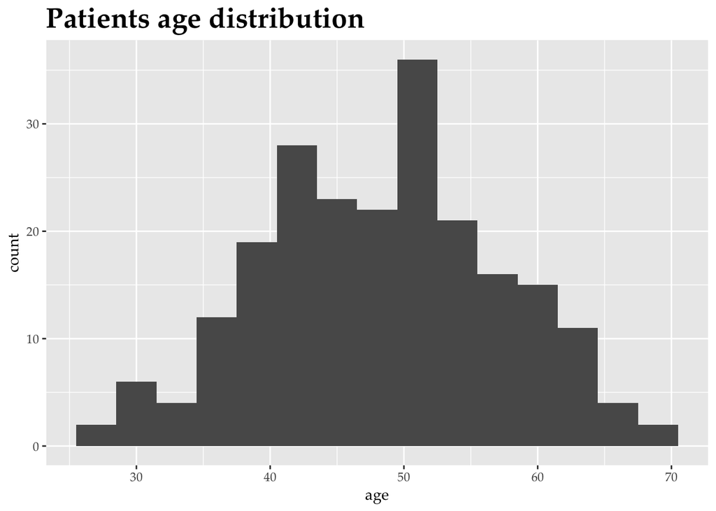

```r
library(ggplot2)
ggplot(data=clinical, aes(x=age)) +
  geom_histogram(binwidth = 3) +
  ggtitle(paste("Patients age distribution")) +
  theme(
    text = element_text(family = "Palatino"),
    plot.title = element_text(hjust = 0, face="bold", size=20))
```

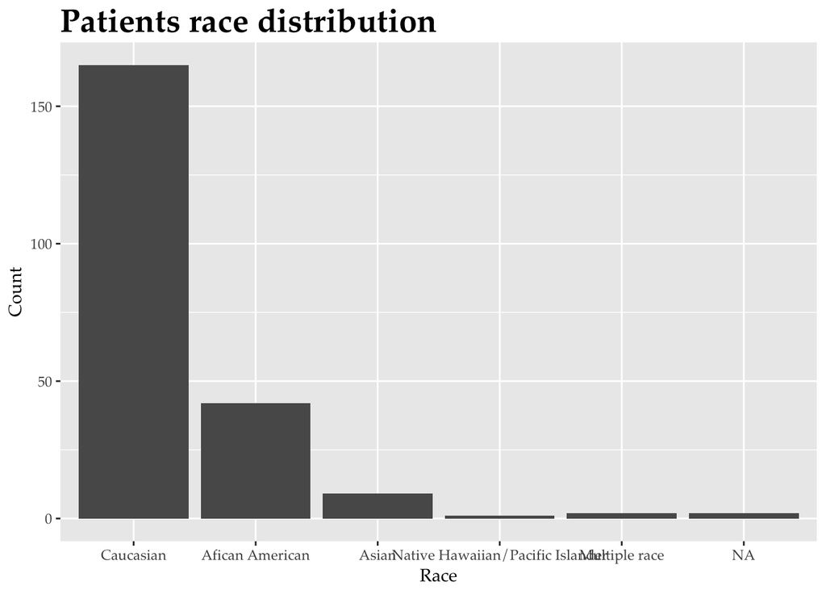

```r
ggplot(data=clinical, aes(x=race_id)) +
  geom_bar() +
  labs(title = "Patients race distribution",
       x = "Race",
       y = "Count") +
  theme(
    text = element_text(family = "Palatino"),
    plot.title = element_text(hjust = 0, face="bold", size=20))
```

### Results

First, I want to look at the survival status of all patients as a whole to see if there is any relationship between survival status and patients age distribution. The result below, however, doesn’t indicate any association of survival status and patients democracy.

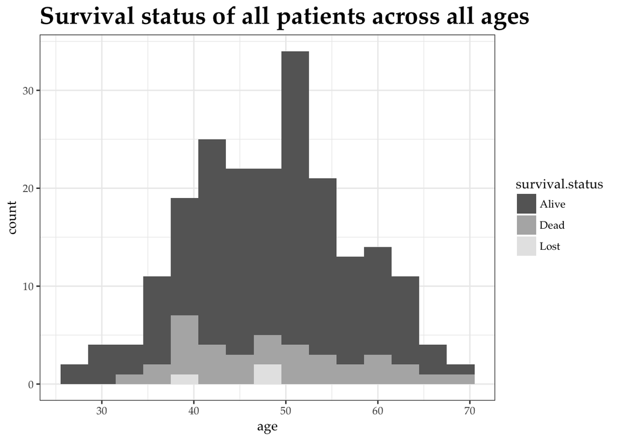

```r
ggplot(data=total, aes(x=age, fill=survival.status)) +
  geom_histogram(binwidth = 3) +
  scale_fill_manual(values=c("gray40", "gray70", "gray90"))+
  theme_bw()+
  ggtitle(paste("Survival status of all patients across all ages")) +
  theme(
    text = element_text(family = "Palatino"),
    plot.title = element_text(hjust = 0, face="bold", size=20))
```

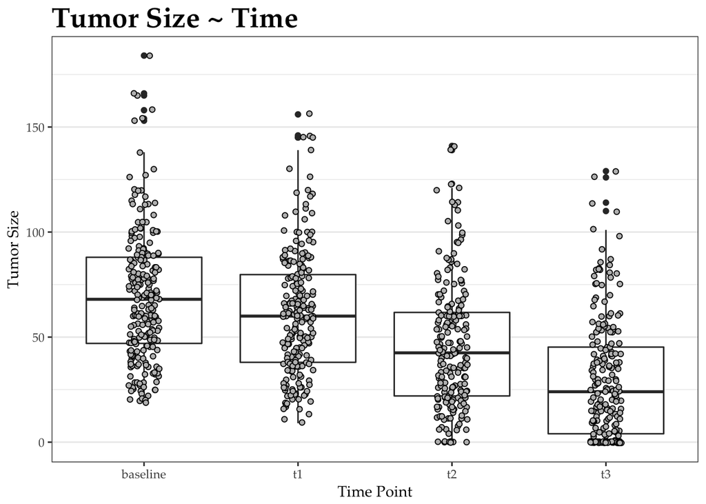

```r
tumor.df <- clinical %>%
  select(SUBJECTID, `MRI LD Baseline`,`MRI LD 1-3dAC`,`MRI LD InterReg`,`MRI LD PreSurg`) %>%
  rename(baseline='MRI LD Baseline', t1='MRI LD 1-3dAC', t2='MRI LD InterReg', t3='MRI LD PreSurg')

tumor.df %>%
  gather(time, size, baseline:t3) %>%
  ggplot(aes(time, size)) +
  geom_boxplot(na.rm = TRUE) +
  geom_jitter(width = 0.1, pch = 21, fill = "grey", na.rm = TRUE) +
  labs(title = "Tumor Size ~ Time",
       x = "Time Point",
       y = "Tumor Size") +
  theme_bw() +
  theme(
    panel.grid.major.x = element_blank(),
    text = element_text(family = "Palatino"),
    plot.title = element_text(face = "bold", size = 20)
  )
```

We also want to take a look at the rate tumor size decreases over time because at different treatment time points, the effect of treatment will be different, and the overall percentage of tumor size might have correlation with PCR an RFS. Below we have a box plot for tumor size percentage change over four different treatment time points, and the results indicate that the tumor decreasing rate will be lowest at the very beginning of the treatment, and the rate will increase over time.

```r
id <- tumor.df["SUBJECTID"]
n <- 3L
id[,2:length(n-2):dim(tumor.df)[2]] <-
  lapply(n:dim(tumor.df)[2], function(x) setNames(((tumor.df[x]-tumor.df[x-1])/tumor.df[x-1]),
                                            paste0("Pct", x-2, x-1)))
```